# Two-Sample Problems (Part 1)

Stanford University, Spring 2016, STATS 205

## Two-Sample Problems

- Two populations
- From each population, we have one sample
- Infer whether or not there is a difference in location between populations
- Measure (with standard error) the difference (size of the effect) between populations
- Test: *Wilcoxon two-sample rank test*
- Estimation procedure: *Hodges–Lehmann estimate*

## Example

```r
library(HSAUR2); head(USmelanoma)
```

```
##             mortality latitude longitude ocean
## Alabama           219     33.0      87.0   yes
## Arizona           160     34.5     112.0    no
## Arkansas          170     35.0      92.5    no
## California        182     37.5     119.5   yes
## Colorado          149     39.0     105.5    no
## Connecticut       159     41.8      72.8   yes
```

Data: Fisher and van Belle (1993) report mortality rates due to malignant melanoma of the skin for white males during the period 1950-1969, for each state on the US mainland

Mortality: Number of white males died due to malignant melanoma 1950-1969 per one million inhabitants

## Example

Question: Is there a difference in mortality for ocean states and non-ocean states?

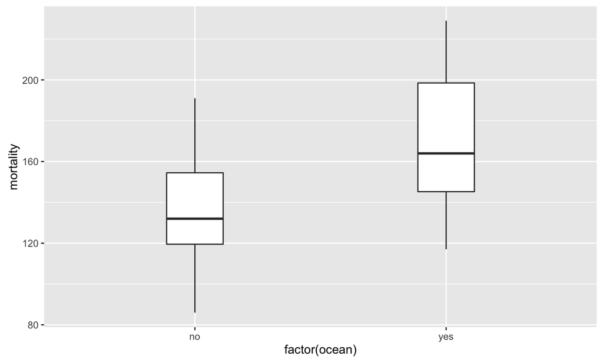

## Wilcoxon for Stochastic Ordering of Alternatives

- Random sample \(X_1,\dots,X_{n_1}\) with cdf \(F\)
- Random sample \(Y_1,\dots,Y_{n_2}\) with cdf \(G\)
- Hypothesis test: \[H_0: F(t) = G(t) \hspace{1cm} \text{versus} \hspace{1cm} H_A: F(t) \le G(t)\]
- For the alternative, \(X\) is stochastically larger than \(Y\): \[\operatorname{P}(X > t) \ge \operatorname{P}(Y > t)\]

## Wilcoxon for Stochastic Ordering of Alternatives

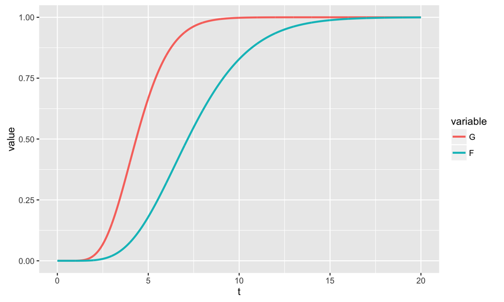

## Wilcoxon for Stochastic Ordering of Alternatives

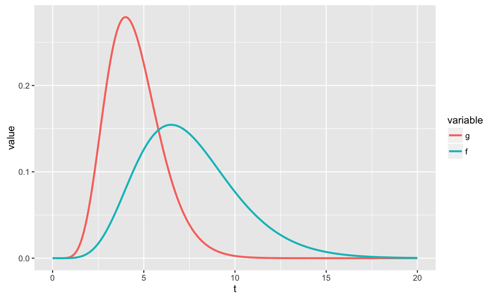

## Wilcoxon for Stochastic Ordering of Alternatives

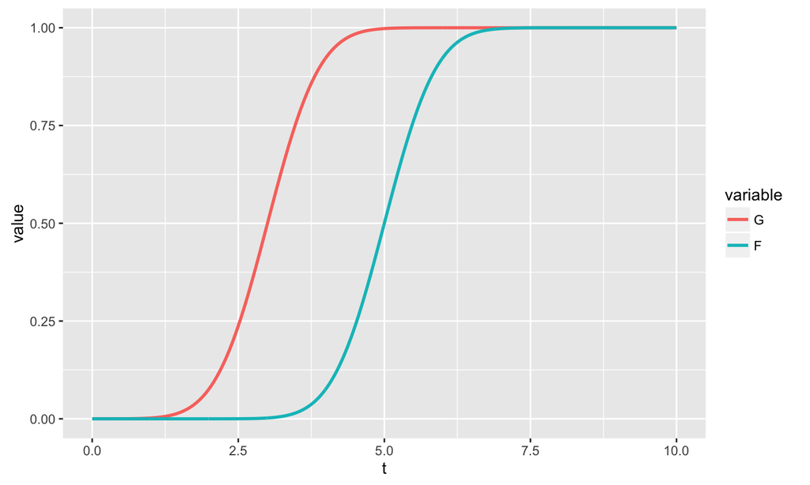

## Wilcoxon for Stochastic Ordering of Alternatives

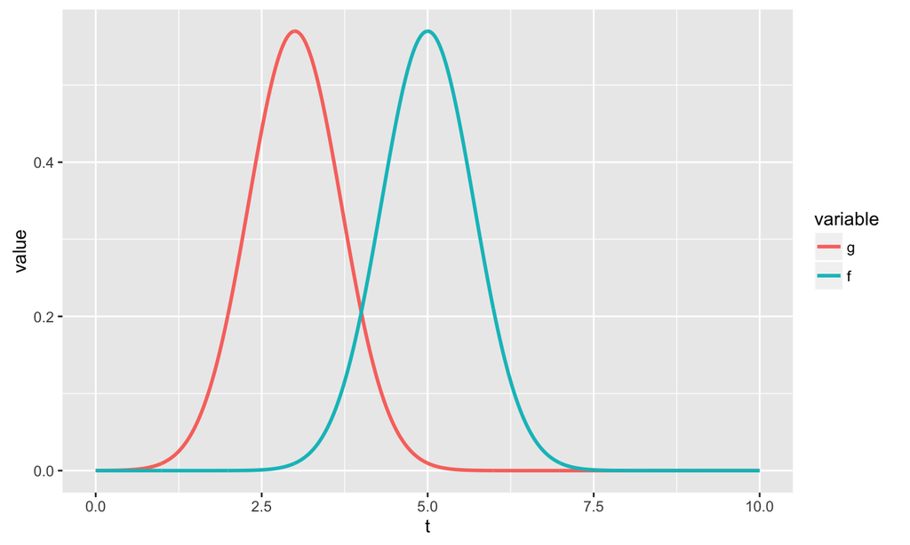

## Wilcoxon for Stochastic Ordering of Alternatives

- Both samples are combined in one sample
- Combinded sample ranked from \(1\) to \(n = n_1+n_2\) (low to high)
- Denote \(\operatorname{R}(Y_j)\) rank of observation \(j\) in combined sample
- The Wilcoxon test statistics \[ T = \sum_{j=1}^{n_2} \operatorname{R}(Y_j)\]
- \(H_0\) is rejected for small values of \(T\)
- Under \(H_0\) the two sample are from the same population:  
  Any subset of ranks is equaliy likely as any other of the same size

## Wilcoxon for Stochastic Ordering of Alternatives

- For example, the probability that a subset of \(n_2\) rankings is assigned to \(Y\)'s is \[\frac{1}{n \choose n_2}\]
- There is no mention of the population distribution, so this test is *distriubiton free*
- So \(p\)-value can be calculated exactly by looking at the distribution of \(T\) or aproximated asymptotically in case of large \(n_1+n_2\)

## Wilcoxon for Stochastic Ordering of Alternatives Example

Data: Case-control study of esophageal cancer in Ile-et-Vilaine, France (Breslow et al. 1980)

Hypothesis: Alcohol consumption same in the two groups

```r
library(datasets); data(esoph); head(esoph)
```

```
##   agegp     alcgp    tobgp ncases ncontrols
## 1 25-34 0-39g/day 0-9g/day      0        40
## 2 25-34 0-39g/day    10-19      0        10
## 3 25-34 0-39g/day    20-29      0         6
## 4 25-34 0-39g/day      30+      0         5
## 5 25-34     40-79 0-9g/day      0        27
## 6 25-34     40-79    10-19      0         7
```

## Wilcoxon for Stochastic Ordering of Alternatives Example

[figure not shown]

## Wilcoxon for Stochastic Ordering of Alternatives Example

```r
wilcox.test(x,y,alternative = "greater")
```

```
##
##  Wilcoxon rank sum test with continuity correction
##
## data:  x and y
## W = 135610, p-value < 2.2e-16
## alternative hypothesis: true location shift is greater than 0
```

Conclusion: Reject the null hypothesis in favor of the alternative that alcohol consumption is higher in participants who suffer from esophageal cancer

## Analyses for a Shift in Location

- Now for two-sample location problem
- The parameter \(\Delta\), for \(-\infty < \Delta < \infty\) is shift in location \[ G(t) = F(t - \Delta) \hspace{1cm} \text{and} \hspace{1cm} g(t) = f(t - \Delta)\]
- For example, difference in means and medians
- Location model assume that the scale parameter of \(X\) and \(Y\) are the same (e.g. variance in normal distribution)

## Analyses for a Shift in Location

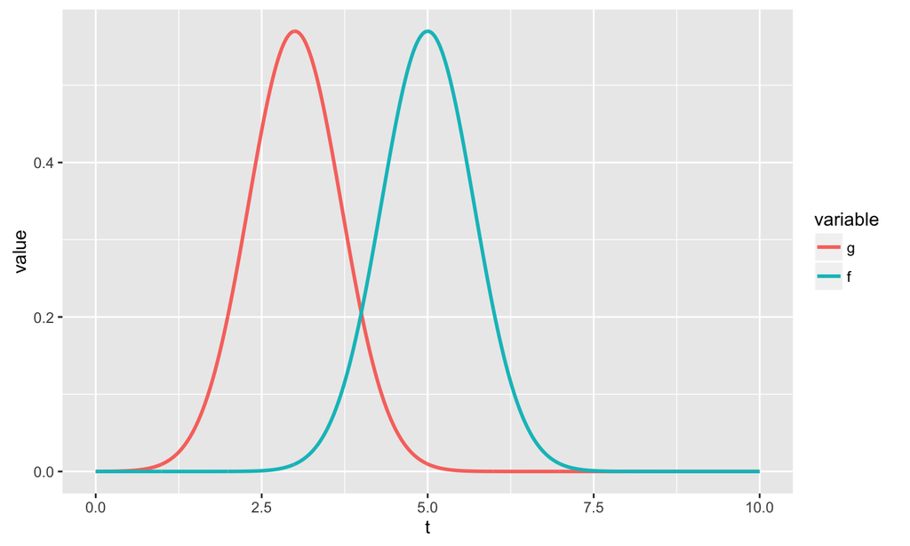

## Analyses for a Shift in Location

- Random sample \(X_1,\dots,X_{n_1}\) with cdf \(F(t)\) and pdf \(f(t)\)
- Random sample \(Y_1,\dots,Y_{n_2}\) with cdf \(F(t-\Delta)\) and pdf \(f(t-\Delta)\)
- Hypothesis test: \[H_0: \Delta = 0 \hspace{1cm} \text{versus} \hspace{1cm} H_A: \Delta \ne 0\]
- Additionally, we can esimate \(\widehat{\Delta}\) and form confidence intervals

## Analyses for a Shift in Location Example

\(t\)-distribution with 5 degrees of freedom and  
a true shift parameter \(\Delta\) was set at the value \(8\)

```r
n1 = 42
n2 = 50
trails = 10
x = round(rt(11,5)*trails+n1,1)
y = round(rt(9,5)*trails+n2,1)
sort(x)
```

```
##  [1] 20.0 27.5 29.7 36.5 41.7 42.1 45.5 46.6 47.9 49.0 50.6
```

```r
sort(y)
```

```
## [1] 25.7 32.4 37.6 38.0 39.4 52.6 55.0 59.7 80.4
```

## Analyses for a Shift in Location Example

Use exact null distribution of \(T+\):

```r
wilcox.test(x,y,exact=TRUE,correct=TRUE)
```

```
##
##  Wilcoxon rank sum test
##
## data:  x and y
## W = 39, p-value = 0.4561
## alternative hypothesis: true location shift is not equal to 0
```

## Analyses for a Shift in Location Example

Use asymptotics:

```r
wilcox.test(x,y,exact=FALSE,correct=FALSE)
```

```
##
##  Wilcoxon rank sum test
##
## data:  x and y
## W = 39, p-value = 0.425
## alternative hypothesis: true location shift is not equal to 0
```

## Permutations and Mann-Whitney

- Rank all \(n_1+n_2\) observations
- Color the first sample red and the second sample blue
- Count how many moves it takes to unscramble the two populations
- *Moves:* pairwise adjacent transpositions
- *Unscrable:* bring all the reds to the left
- Few moves, things were pretty well sorted, we have grounds for believing the numbers were drawn from different populations
- If observations were drawn from the same population, they should be well intermingled and require many moves to unscramble
- This test which is equivalent to the popular Mann Whitney statistic
- Reference: Critchlow (1986), *A Unified Approach to Constructing Nonparametric Rank Tests* [(Link)](https://statistics.stanford.edu/research/unified-approach-constructing-nonparametric-rank-tests)

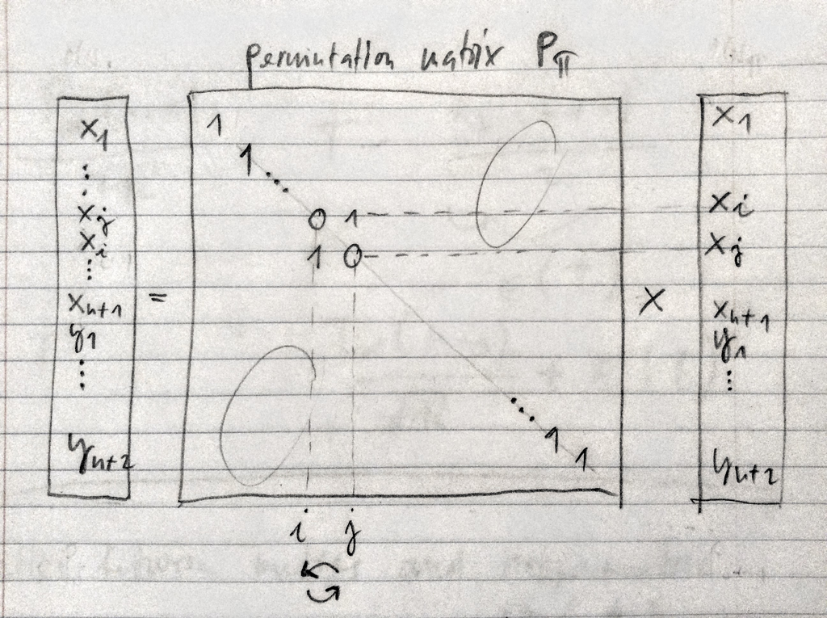